# 1-r-intro-cn

## 基本作图

一图胜千言

- 人类非常善于从视觉呈现中洞察关系。
- 一幅精心绘制的图形能够帮助你在数以千计的零散信 息中做出有意义的比较，提炼出使用其他方法时不那么容易发现的模式。
- R是一个惊艳的图形构建平台。在通常的交互式会话中，我们可 以通过逐条输入语句构建图形，逐渐完善图形特征，直至得到想要的效果。
- `plot()`是R中为对象作图的一个泛型函数(它的输出将根据所绘制对象类型的不同而变化)。

`plot(x, y)`, 将x置于横轴，将y置于纵轴，绘制点集(x, y)，散点图。使用help(plot)可以查看其他选项。

下面的代码打开一个图形窗口并生成了一幅散点图，横轴表 示车身重量，纵轴为每加仑汽油行驶的英里数。

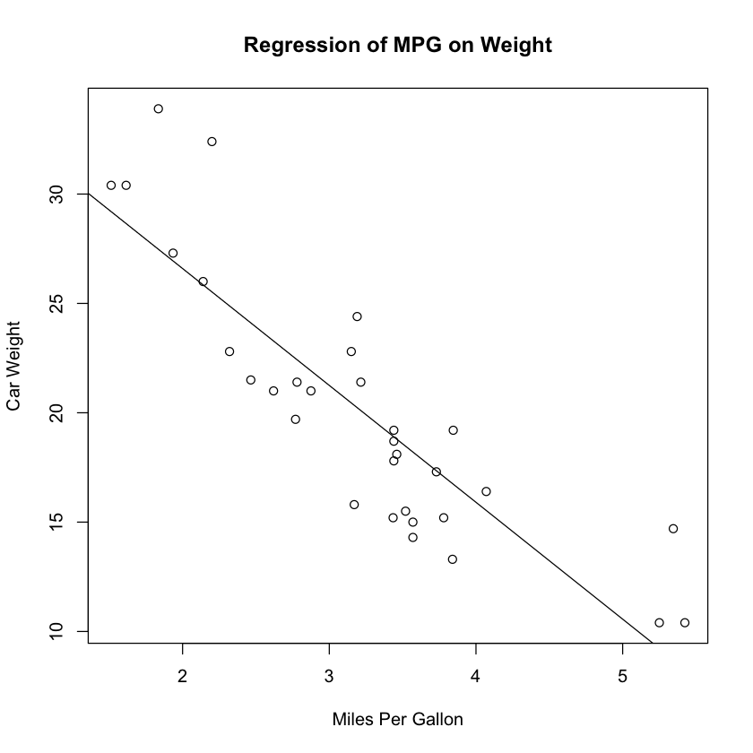

```r
plot(mtcars$wt, mtcars$mpg,
     xlab="Miles Per Gallon",
     ylab="Car Weight")
abline(lm(mtcars$mpg~mtcars$wt))
title("Regression of MPG on Weight")
```

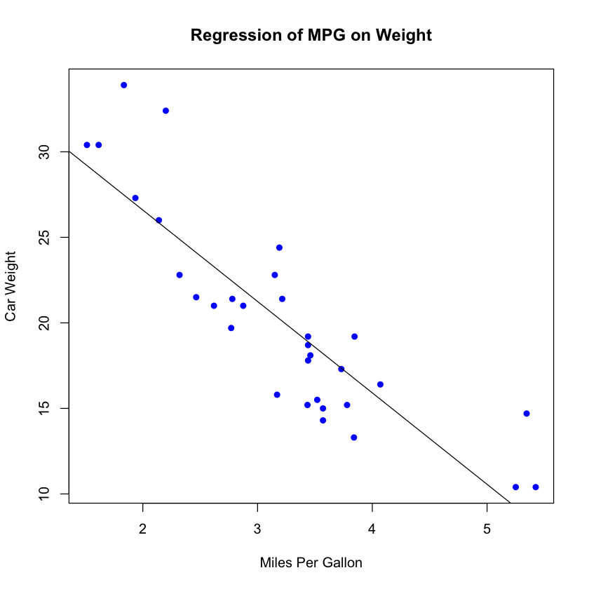

```r
plot(mtcars$wt, mtcars$mpg,
         xlab="Miles Per Gallon",
         ylab="Car Weight",
     col=4,
     pch=16)
abline(lm(mtcars$mpg~mtcars$wt))
title("Regression of MPG on Weight")
```

有这些形状可以选择：

[figure not shown]

总是用美元符号，是不是太麻烦？换一种方式：

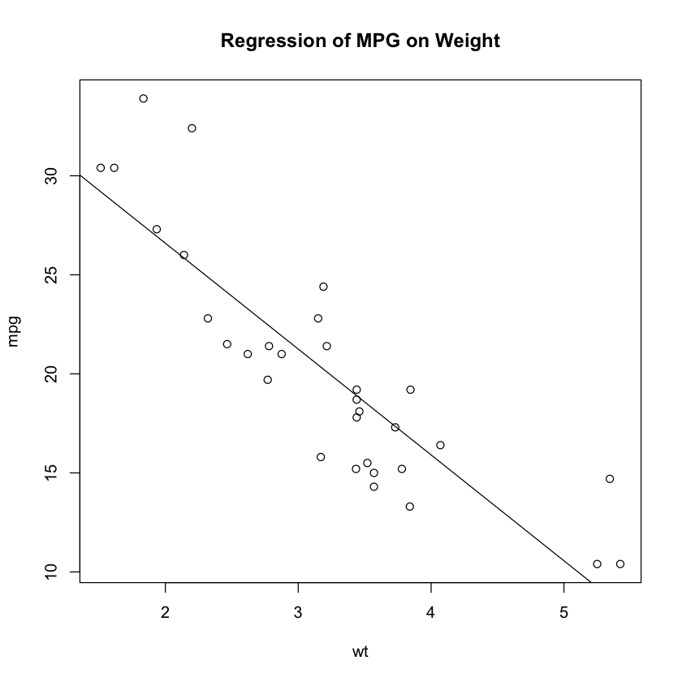

```r
with(mtcars,{
plot(wt, mpg)
abline(lm(mpg~wt))
title("Regression of MPG on Weight")
}
)
```

全局参数设定，多图同列, 例如设置2列2行， 四个直方图：

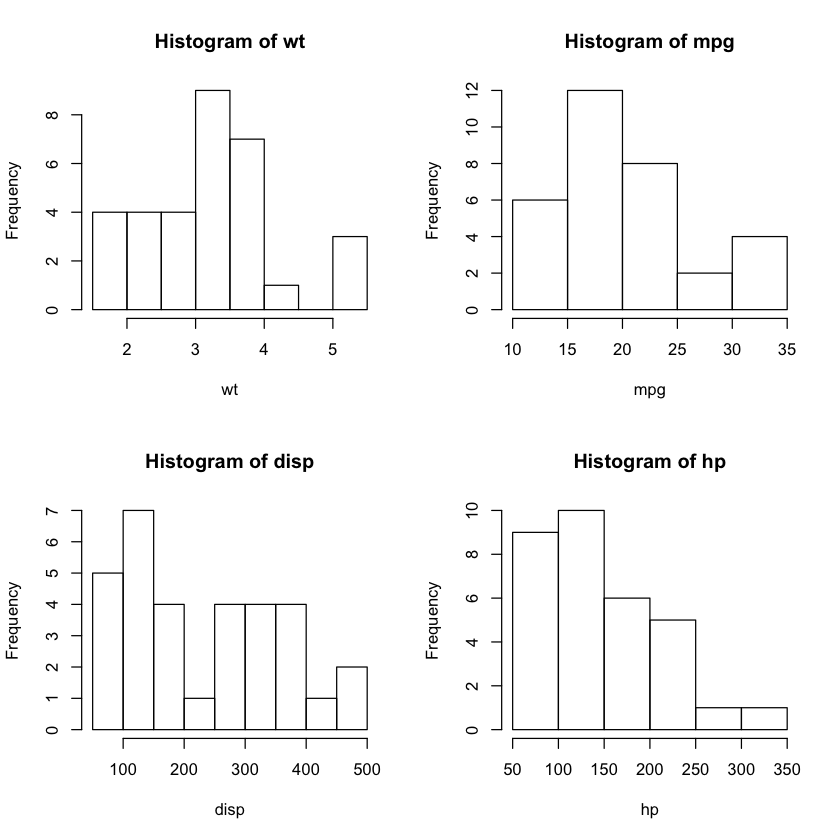

```r
with(mtcars,{
  par(mfrow=c(2,2))
  hist(wt)
  hist(mpg)
  hist(disp)
  hist(hp)
})
```

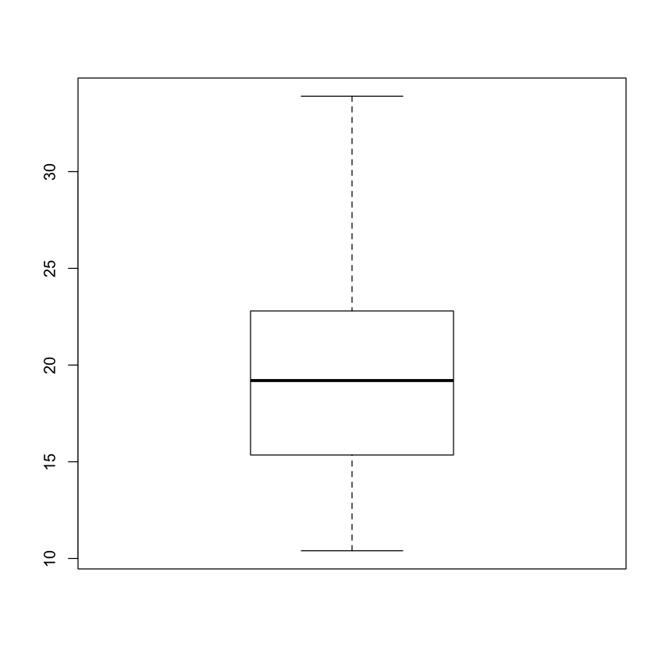

```r
boxplot(mtcars$mpg)
```